# Ecological Forecasting Lab 4 - RMSE of AR(1) Models

Seth Romero

2023-02-13

### Models from Lab 3…

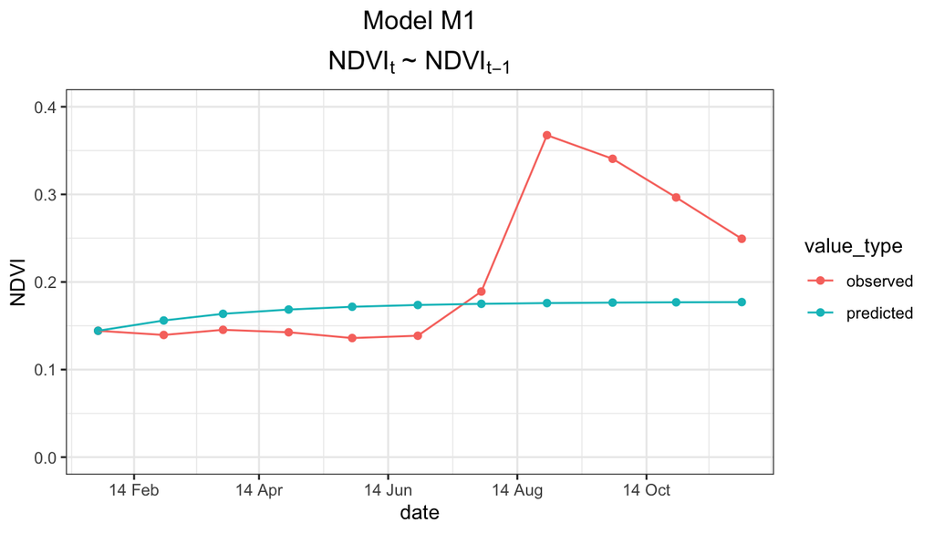

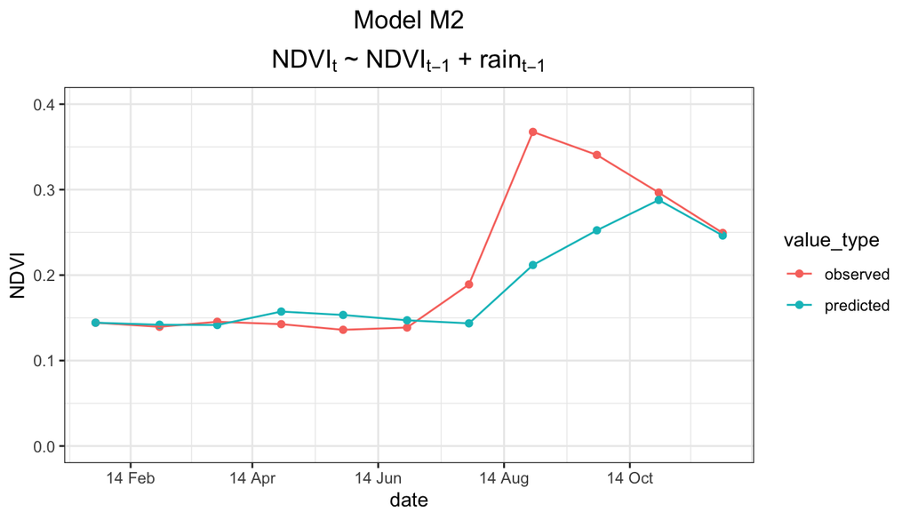

*Calculate RMSE of both NDVI forecasts.*  
*Do this cumulative across month.*  
*E.g. Month 1, then Month 1 and 2, then 1, 2, and 3, etc.*

Interpreting this as a sort of calculated *progression* of RMSE as you include more forecasted values. Increases or decreases in this value, as you move from month 1 to month 10, indicates which months are contributing to increased or decreased model accuracy relative to the accuracy across all previously forecasted months.

```r
rmse <- function(y.hat, y.obs){
  error = numeric(length(y.obs))
  error[1] = 0
  residSum = 0
  for (t in 2:length(y.obs)){
    residSum = residSum + (y.hat[t] - y.obs[t])^2
    error[t] = sqrt(residSum / (t-1))
  }
  return(error)
}

pred_ts1 <- pred_ts1 %>%
  pivot_wider(names_from = "value_type", values_from = "NDVI") %>%
  mutate(RMSE = rmse(y.hat = predicted,
                     y.obs = observed))

pred_ts2 <- pred_ts2 %>%
  pivot_wider(names_from = "value_type", values_from = "NDVI") %>%
  mutate(RMSE = rmse(y.hat = predicted,
                     y.obs = observed))

tail(pred_ts1, n=10)
```

```
## # A tibble: 10 × 4
##    date       observed predicted   RMSE
##    <date>        <dbl>     <dbl>  <dbl>
##  1 2014-02-15    0.140     0.156 0.0165
##  2 2014-03-15    0.145     0.164 0.0174
##  3 2014-04-15    0.143     0.169 0.0207
##  4 2014-05-15    0.136     0.172 0.0253
##  5 2014-06-15    0.139     0.174 0.0275
##  6 2014-07-15    0.189     0.175 0.0258
##  7 2014-08-15    0.368     0.176 0.0763
##  8 2014-09-15    0.341     0.176 0.0920
##  9 2014-10-15    0.296     0.177 0.0954
## 10 2014-11-15    0.249     0.177 0.0934
```

```r
tail(pred_ts2, n=10)
```

```
## # A tibble: 10 × 5
##    date        rain observed predicted    RMSE
##    <date>     <dbl>    <dbl>     <dbl>   <dbl>
##  1 2014-02-15   1.3    0.140     0.142 0.00241
##  2 2014-03-15  21.6    0.145     0.142 0.00319
##  3 2014-04-15   5      0.143     0.157 0.00890
##  4 2014-05-15   0      0.136     0.153 0.0116
##  5 2014-06-15   0      0.139     0.147 0.0110
##  6 2014-07-15  89.5    0.189     0.144 0.0212
##  7 2014-08-15  91.3    0.368     0.212 0.0620
##  8 2014-09-15 107.     0.341     0.252 0.0659
##  9 2014-10-15  27.9    0.296     0.288 0.0622
## 10 2014-11-15   7.6    0.249     0.246 0.0590
```

*What month do the forecasts diverge? why?*

Both forecasts diverge from observed values most dramatically in the mid-July to mid-August interval. This is seen visually as forecasted NDVI for both models strongly underestimates the increase in observed NDVI at mid-August. Intuitively, this underestimation makes sense. A dramatic increase in observed NDVI is likely to occur once per year (or once per 12 month intervals). Because this is an AR(*1*) model (i.e. predicted values are only a funciton of *one* time interval prior), there are usually multiple month-periods per year where NDVI does not increase dramatically but the prior period is high (e.g. late-summer or early-fall), so $\beta_1$ is a balance of a single sharp increase and prolonged stable-but-high period. This is a typical annual pattern which leads to an *under*estimation of large single-interval increases but maximized fit in periods where NDVI is stable-but-high. Accounting for a variable like rain (which helps account for prolonged high values of NDVI independent of previous NDVI interval) leads to better model fit over this stable-but-high NDVI period.

The increase in RMSE after mid-July is seen in both models. However, error is reduced in all periods by the inclusion of rain<sub>t-1</sub>. Interestingly, rain improves prediction in periods where NDVI fluctuation and absolute values are low suggesting that even small amounts of moisture lead to predictable effects on vegetation in the non-growing season. M2 RMSE also decreases quicker than M1 after the large NDVI increase in August suggesting that rain in M2 leads to improved overall fit when including periods of high absolute NDVI.

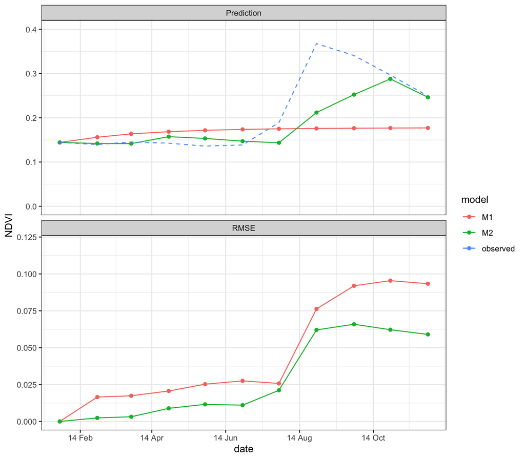

*Create predicted vs observed plots*

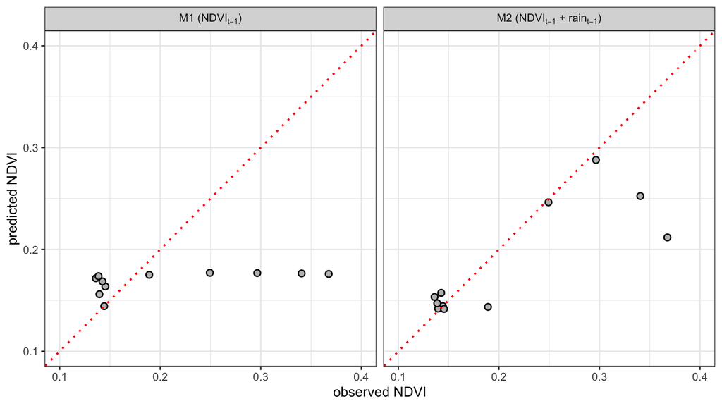

```r
ggplot(data = subset(pred_comb, valuetype == "Prediction"), aes(x = observed, y = NDVI)) +
  geom_point(shape = 21, size = 2, fill = "gray", stroke = 0.75) +
  facet_wrap(~ title, labeller = label_parsed) +
  geom_abline(intercept = 0, slope = 1, linetype = "dotted", linewidth = 0.75, color = "red") +
  scale_x_continuous(limits = c(0.1, 0.4)) +
  scale_y_continuous(limits = c(0.1, 0.4)) +
  theme_bw() +
  labs(x = "observed NDVI", y = "predicted NDVI")
```